# Tree size, exposure, and hydraulic traits interactively shape drought response in a temperate broadleaf forest

# Discussion

### misc content to integrate

From (Kannenberg et al. 2019), species with diffuse porous wood anatomy (*Liriodendron*) are more sensitive to drought, whereas ring-porous are not as affected because they more easily rebuild structures for hydraulic conductivity. This paper mentions it would be good to have this data with respect to latent affects from drought.

# Conclusion

# Supplementary Information

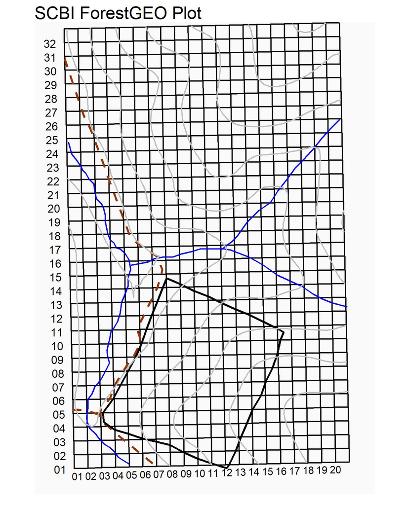

Structure of ForestGEO plot

### p50 and p80

(see Issue #32)

**other sources???**

# References

National Ecological Observatory Network. [2019]. Data Products: [DP1.00002.001, DP1.00001.001, DP1.00005.001, DP1.00098.001, DP1.00014.001]. Provisional data downloaded from http://data.neonscience.org on [2019-06-13]. Battelle, Boulder, CO, USA

Anderegg, William R. L., Tamir Klein, Megan Bartlett, Lawren Sack, Adam F. A. Pellegrini, Brendan Choat, and Steven Jansen. 2016. “Meta-Analysis Reveals That Hydraulic Traits Explain Cross-Species Patterns of Drought-Induced Tree Mortality Across the Globe.” *Proceedings of the National Academy of Sciences* 113 (18): 5024–9. https://doi.org/10.1073/pnas.1525678113.

Anderson‐Teixeira, Kristina J., Stuart J. Davies, Amy C. Bennett, Erika B. Gonzalez‐Akre, Helene C. Muller‐Landau, S. Joseph Wright, Kamariah Abu Salim, et al. 2015. “CTFS-ForestGEO: A Worldwide Network Monitoring Forests in an Era of Global Change.” *Global Change Biology* 21 (2): 528–49. https://doi.org/10.1111/gcb.12712.

Anderson‐Teixeira, Kristina J., Jennifer C. McGarvey, Helene C. Muller‐Landau, Janice Y. Park, Erika B. Gonzalez‐Akre, Valentine Herrmann, Amy C. Bennett, et al. 2015. “Size-Related Scaling of Tree Form and Function in a Mixed-Age Forest.” *Functional Ecology* 29 (12): 1587–1602. https://doi.org/10.1111/1365-2435.12470.

Bates, Douglas, Martin Maechler, Ben Bolker, and Steven Walker. 2019. *Lme4: Linear Mixed-Effects Models Using ’Eigen’ and S4*. https://CRAN.R-project.org/package=lme4.

Bennett, Amy C., Nathan G. McDowell, Craig D. Allen, and Kristina J. Anderson-Teixeira. 2015. “Larger Trees Suffer Most During Drought in Forests Worldwide.” *Nature Plants* 1 (10): 15139. https://doi.org/10.1038/nplants.2015.139.

Bourg, Norman A., William J. McShea, Jonathan R. Thompson, Jennifer C. McGarvey, and Xiaoli Shen. 2013. “Initial Census, Woody Seedling, Seed Rain, and Stand Structure Data for the SCBI SIGEO Large Forest Dynamics Plot.” *Ecology* 94 (9): 2111–2. https://doi.org/10.1890/13-0010.1.

Gonzalez‐Akre, Erika, Victoria Meakem, Cheng-Yin Eng, Alan J. Tepley, Norman A. Bourg, William McShea, Stuart J. Davies, and Kristina Anderson‐Teixeira. 2016. “Patterns of Tree Mortality in a Temperate Deciduous Forest Derived from a Large Forest Dynamics Plot.” *Ecosphere* 7 (12): e01595. https://doi.org/10.1002/ecs2.1595.

Helcoski, Ryan, Alan J. Tepley, Neil Pederson, Jennifer C. McGarvey, Victoria Meakem, Valentine Herrmann, Jonathan R. Thompson, and Kristina J. Anderson‐Teixeira. 2019. “Growing Season Moisture Drives Interannual Variation in Woody Productivity of a Temperate Deciduous Forest.” *New Phytologist* 0 (0). https://doi.org/10.1111/nph.15906.

Jennings, S. B., N. D. Brown, and D. Sheil. 1999. “Assessing Forest Canopies and Understorey Illumination: Canopy Closure, Canopy Cover and Other Measures.” *Forestry: An International Journal of Forest Research* 72 (1): 59–74. https://doi.org/10.1093/forestry/72.1.59.

Kannenberg, Steven A., Kimberly A. Novick, M. Ross Alexander, Justin T. Maxwell, David J. P. Moore, Richard P. Phillips, and William R. L. Anderegg. 2019. “Linking Drought Legacy Effects Across Scales: From Leaves to Tree Rings to Ecosystems.” *Global Change Biology* 0 (ja). https://doi.org/10.1111/gcb.14710.

Larjavaara, Markku, and Helene C. Muller‐Landau. 2013. “Measuring Tree Height: A Quantitative Comparison of Two Common Field Methods in a Moist Tropical Forest.” *Methods in Ecology and Evolution* 4 (9): 793–801. https://doi.org/10.1111/2041-210X.12071.

Lloret, Francisco, Eric G. Keeling, and Anna Sala. 2011. “Components of Tree Resilience: Effects of Successive Low-Growth Episodes in Old Ponderosa Pine Forests.” *Oikos* 120 (12): 1909–20. https://doi.org/10.1111/j.1600-0706.2011.19372.x.

Mazerolle, Marc J., and portions of code contributed by Dan Linden. 2019. *AICcmodavg: Model Selection and Multimodel Inference Based on (Q)AIC(c)*. https://CRAN.R-project.org/package=AICcmodavg.

Metcalfe, Peter, Keith Beven, and Jim Freer. 2018. *Dynatopmodel: Implementation of the Dynamic Topmodel Hydrological Model*. https://CRAN.R-project.org/package=dynatopmodel.

Scharnweber, Tobias, Lisa Heinze, Roberto Cruz-García, Marieke van der Maaten-Theunissen, and Martin Wilmking. 2019. “Confessions of Solitary Oaks: We Grow Fast but We Fear the Drought.” *Dendrochronologia* 55 (June): 43–49. https://doi.org/10.1016/j.dendro.2019.04.001.

Slette, Ingrid J., Alison K. Post, Mai Awad, Trevor Even, Arianna Punzalan, Sere Williams, Melinda D. Smith, and Alan K. Knapp. 2019. “How Ecologists Define Drought, and Why We Should Do Better.” *Global Change Biology* 0 (0): 1–8. https://doi.org/10.1111/gcb.14747.

Stovall, Atticus E. L., Kristina J. Anderson-Teixeira, and Herman H. Shugart. 2018a. “Terrestrial LiDAR-Derived Non-Destructive Woody Biomass Estimates for 10 Hardwood Species in Virginia.” *Data in Brief* 19 (August): 1560–9. https://doi.org/10.1016/j.dib.2018.06.046.

———. 2018b. “Assessing Terrestrial Laser Scanning for Developing Non-Destructive Biomass Allometry.” *Forest Ecology and Management* 427 (November): 217–29. https://doi.org/10.1016/j.foreco.2018.06.004.

Suarez, Maria Laura, Luciana Ghermandi, and Thomas Kitzberger. 2004. “Factors Predisposing Episodic Drought-Induced Tree Mortality in Nothofagus– Site, Climatic Sensitivity and Growth Trends.” *Journal of Ecology* 92 (6): 954–66. https://doi.org/10.1111/j.1365-2745.2004.00941.x.

van der Maaten-Theunissen, Marieke, and Ernst van der Maaten. 2016. *PointRes: Analyzing Pointer Years and Components of Resilience*. https://CRAN.R-project.org/package=pointRes.